# perio-analysis

```python
%matplotlib inline
# note to self: in order to strip the passwords from a shareable HTML version of this
# notebook, tag unwanted cells 'remove_cell" and execute this in the terminal:
# jupyter nbconvert perio-analysis.ipynb --TagRemovePreprocessor.remove_cell_tags='{"remove_cell"}'

from py2neo import Graph as Graph, NodeMatcher
import seaborn as sns
import pandas as pd
from matplotlib import pyplot as plt

import cx_Oracle
```

This document compares our Axium data on whether a patient has diabetes to the graph database is able to identify them based on the concepts within, linked back to a network representation of the UMLS. The Axium select looks for the identifiers our research scientists usually apply when searching the database. The Neo4j select starts with the UMLS concepts and works backwards toward the patient. The **Graph Proof-of-Concept** patients are being held in a Neo4j database. These are the 8700 patients who visited the school in January 2018.

```python
graph_patients = pd.DataFrame(g.nodes.match('Patient'))
graph_patients.loc[graph_patients.age.isna(), 'age'] = 0

graph_patients.age = graph_patients.age.astype('int32')

graph_patients.age.describe()
```

```
count    8763.000000
mean       47.260984
std        21.687737
min         0.000000
25%        27.000000
50%        50.000000
75%        66.000000
max       101.000000
Name: age, dtype: float64
```

The **Axium Patients** are all patients who visited the school in the last five years. I didn't do the full text parsing or network logic over them, but instead did a brute-force extract of anyone with the word 'diab*', 'insulin', or 'humulin' in their valid histories

```python
ax_patients = pd.read_sql("""
SELECT DISTINCT p."Patient",
                extract(year from to_date('2018-01-01', 'YYYY-MM-DD')) - extract(year from p."Birth") as Age,
                decode(p."Sex", 1, 'M', 2, 'F', 'O')                                                  as Sex,
                r.perio_indications,
                pi.diab_indications

from AXIUM.PATIENT p
         left join (select a."Patient", max(a."Date") apt_date
                    FROM AXIUM.APPOINT a
                    group by a."Patient") q
                   on q."Patient" = p."Patient"

         left join (select distinct "Patient",
                                    1 as perio_indications
                    from TRX t
                    where t."Procedure" = 'D4700'
                       or t."Procedure" = 'D4800') r
                   on r."Patient" = p."Patient"

         left join (
                    SELECT DISTINCT pi."Patient",
                                    1 as diab_indications
--                                     , fi."AnsType", pi."AnsYes", pi."AnsText", fi."Text"
                    FROM PITEM pi
                             left join FITEM fi on pi."FItem" = fi."FItem"
                    where (lower(pi."AnsText") LIKE '%diabet%'
                        or lower(pi."AnsText") LIKE '%insulin%'
                        or lower(pi."AnsText") like '%humulin%'
                        or lower(pi."AnsText") like '%gluco%'
                        or lower(fi."Text") like '%diabet%')
                      AND "Status" = 0
                      AND fi."FormCode" = 'HEALTH'
                      AND (fi."AnsType" = 5
                        or (fi."AnsType" = 0 and "AnsYes" = 1))
                    GROUP BY pi."Patient"
                ) pi
                   on pi."Patient" = p."Patient"

where p."Status" = 'ACTIVE'
  and q.apt_date >= to_date('2014-08-01', 'YYYY-MM-DD')
""", con = ax_con)
```

```python
ax_patients.columns = ['patient', 'age', 'sex', 'perio_indications', 'diab_indications']

ax_patients.loc[ax_patients.age.isna(), 'age'] = 0
ax_patients = ax_patients.fillna(0)
ax_patients.head()
```

|  | patient | age | sex | perio_indications | diab_indications |
| --- | --- | --- | --- | --- | --- |
| 0 | na | 82.0 | M | 1.0 | 0.0 |
| 1 | na | 80.0 | M | 1.0 | 0.0 |
| 2 | na | 64.0 | M | 1.0 | 0.0 |
| 3 | na | 55.0 | F | 1.0 | 0.0 |
| 4 | na | 57.0 | F | 1.0 | 0.0 |

Here are plots comparing the distribution of ages among the two datasets. Similar, but not by any means identical.

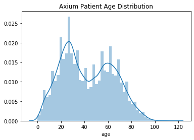

```python
sns.distplot(ax_patients.age).set_title('Axium Patient Age Distribution')
```

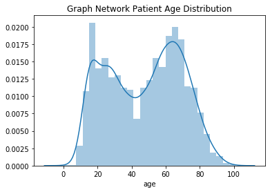

```python
sns.distplot(graph_patients.age).set_title('Graph Network Patient Age Distribution')
```

Here, I grab ask the Graph database to get all patients within three hops of a concept whose hame includes diabetes, insulin, or humulin. I also got cardio pts although I don't use the data in this analysis

```python
diabetes_qy = """match path = (c1:Concept)<-[:ISA*0..3]-(c2)
where tolower(c1.str) contains 'diabet'
or (tolower(c1.str) contains 'insulin' or tolower(c1.str) contains 'humulin')
with c2 match (p:Patient)--(c2)
return p.patient as patient, c2.str as diab_indications;"""

cardio_qy = """match path = (c1:Disease_or_Syndrome)<-[:ISA*0..3]-(c2)
where tolower(c1.str) contains 'heart' or tolower(c1.str) contains 'cardio'
with c2 match (p:Patient)--(c2)
return p.patient as patient, c2.str as cardio_indications;"""

perio_qy = """match (p:Patient)--(pr:Procedure)
where pr.procedure starts with 'D47'
or pr.procedure starts with 'D48'
return p.patient as patient, pr.procedure as perio_indications"""
```

```python
diabetes_pts = g.run(diabetes_qy).to_data_frame().groupby('patient').count()

cardio_pts = g.run(cardio_qy).to_data_frame().groupby('patient').count()

perio_pts = g.run(perio_qy).to_data_frame().groupby('patient').count()
```

```python
print(len(diabetes_pts),
      len(cardio_pts),
      len(perio_pts))
```

```
942 3040 846
```

```python
graph_patients = graph_patients.join(diabetes_pts, on = 'patient').join(cardio_pts, on = 'patient').join(perio_pts,on = 'patient')

graph_patients.head()
```

|  | age | community | patient | sex | diab_indications | cardio_indications | perio_indications |
| --- | --- | --- | --- | --- | --- | --- | --- |
| 0 | 15 | NaN | na | F | NaN | NaN | NaN |
| 1 | 31 | NaN | na | F | NaN | NaN | NaN |
| 2 | 63 | NaN | na | M | NaN | 2.0 | NaN |
| 3 | 80 | NaN | na | F | NaN | NaN | NaN |
| 4 | 63 | NaN | na | M | NaN | NaN | NaN |

```python
def f(x):
    if x > 0:
        return True
    else: return False
```

```python
vals=graph_patients[['age','sex', 'diab_indications', 'perio_indications']]
vals=vals[vals.sex != 'O']

vals = vals.fillna(0)

ax_vals = ax_patients[['age','sex', 'diab_indications', 'perio_indications']]
ax_vals = ax_vals[ax_vals.sex != 'O']

for col in ['diab_indications', 'perio_indications']:
    vals[col] = vals[col].apply(f)
    ax_vals[col] = ax_vals[col].apply(f)

vals['age'] = vals['age'].apply(lambda x: '60+' if x >= 60 else 'Under 60')
ax_vals['age'] = ax_vals['age'].apply(lambda x: '60+' if x >= 60 else 'Under 60')
```

Here, I cross-tabulate the different sub-populations for the **Graph** Group

```python
cross = pd.crosstab(index = [vals['perio_indications'],
                     vals['sex']],
           columns = [vals['diab_indications'],
                      vals['age']],
            margins = False)

cross
```

| perio_indications | diab_indications age sex | False 60+ | False Under 60 | True 60+ | True Under 60 |
| --- | --- | --- | --- | --- | --- |
| False | F | 1114 | 2800 | 233 | 162 |
|  | M | 986 | 2244 | 245 | 130 |
| True | F | 187 | 115 | 57 | 15 |
|  | M | 235 | 138 | 73 | 26 |

```python
cross.apply(lambda r: r/cross.to_numpy().sum(), axis=1).style.format("{:.2%}")
```

| perio_indications | diab_indications age sex | False 60+ | False Under 60 | True 60+ | True Under 60 |
| --- | --- | --- | --- | --- | --- |
| False | F | 12.72% | 31.96% | 2.66% | 1.85% |
|  | M | 11.26% | 25.62% | 2.80% | 1.48% |
| True | F | 2.13% | 1.31% | 0.65% | 0.17% |
|  | M | 2.68% | 1.58% | 0.83% | 0.30% |

```python
cross.to_numpy().sum()
```

```
8760
```

And then the same breakdown for the **Axium** Group

```python
ax_cross = pd.crosstab(index = [ax_vals['perio_indications'],
                     ax_vals['sex']],
           columns = [ax_vals['diab_indications'],
                      ax_vals['age']],
            margins = False)

ax_cross
```

[output not shown]

```python
ax_cross.apply(lambda r: r/ax_cross.to_numpy().sum(), axis=1).style.format("{:.2%}")
```

| perio_indications | diab_indications age sex | False 60+ | False Under 60 | True 60+ | True Under 60 |
| --- | --- | --- | --- | --- | --- |
| False | F | 11.29% | 38.19% | 1.81% | 1.45% |
|  | M | 9.57% | 30.79% | 1.66% | 1.05% |
| True | F | 0.85% | 0.61% | 0.27% | 0.10% |
|  | M | 1.07% | 0.79% | 0.37% | 0.13% |

```python
ax_cross.to_numpy().sum()
```

```
93356
```

These plots replicate the information above but in a more visual way. First the Graph network, then Axium

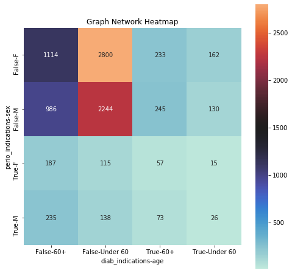

```python
fig, ax = plt.subplots(figsize = (8,8))
sns.heatmap(cross,  center = 1500, annot = True, fmt = 'd',ax = ax,  square = True).set_title('Graph Network Heatmap')
```

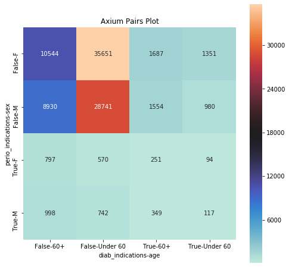

```python
fig, ax = plt.subplots(figsize = (8,8))
sns.heatmap(ax_cross, center = 18000, annot = True, fmt = 'd',ax = ax,  square = True).set_title('Axium Pairs Plot')
```